# 6. Leslie matrices

Beth Babcock

2026-09-10

```r
library(tidyverse)
theme_set(theme_bw())
```

### Life table calculations

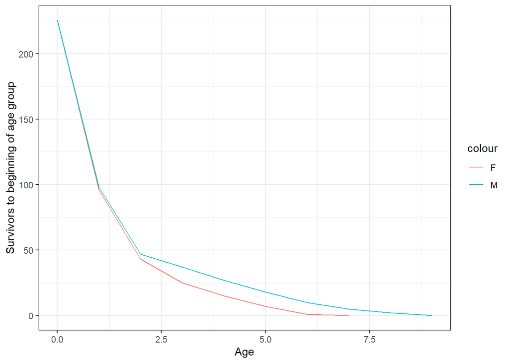

```r
cohort<-read_csv("cohortLifeTable.csv")
ggplot(cohort,aes(x=x))+
  geom_line(aes(y=S_F,color="F"))+
  geom_line(aes(y=S_M,color="M"))+
  labs(x="Age",y="Survivors to beginning of age group")
```

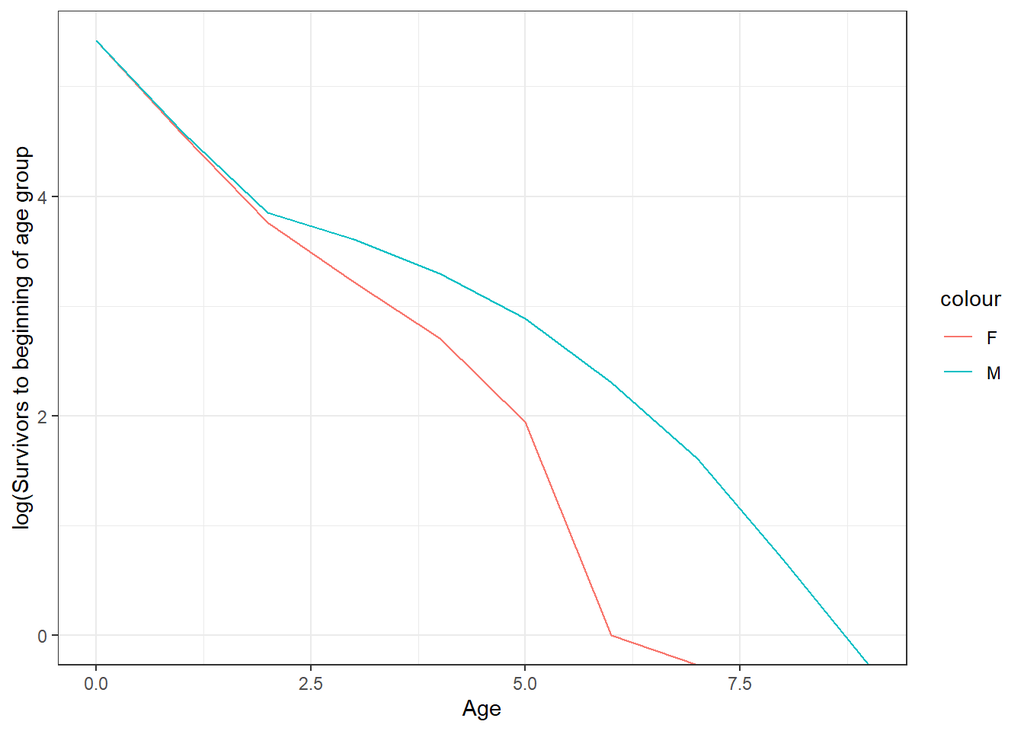

```r
ggplot(cohort,aes(x=x))+
  geom_line(aes(y=log(S_F),color="F"))+
  geom_line(aes(y=log(S_M),color="M"))+
  labs(x="Age",y="log(Survivors to beginning of age group")
```

Calculate number of deaths

```r
cohort$D_M<-cohort$S_M-c(cohort$S_M[2:10],0)
cohort$D_F<-cohort$S_F-c(cohort$S_F[2:10],0)
cohort
```

```
## # A tibble: 10 × 5
##        x   S_M   S_F   D_M   D_F
##    <dbl> <dbl> <dbl> <dbl> <dbl>
##  1     0  226.  226.  128.  130.
##  2     1   98    96    51    53
##  3     2   47    43    10    18
##  4     3   37    25    10    10
##  5     4   27    15     9     8
##  6     5   18     7     8     6
##  7     6   10     1     5     1
##  8     7    5     0     3    NA
##  9     8    2    NA     2    NA
## 10     9    0    NA     0    NA
```

Calculate mortality rate

```r
cohort<-cohort |> mutate(
  q_M=D_M/S_M,
  q_F=D_F/S_F)
cohort
```

```
## # A tibble: 10 × 7
##        x   S_M   S_F   D_M   D_F     q_M    q_F
##    <dbl> <dbl> <dbl> <dbl> <dbl>   <dbl>  <dbl>
##  1     0  226.  226.  128.  130.   0.565  0.574
##  2     1   98    96    51    53    0.520  0.552
##  3     2   47    43    10    18    0.213  0.419
##  4     3   37    25    10    10    0.270  0.4
##  5     4   27    15     9     8    0.333  0.533
##  6     5   18     7     8     6    0.444  0.857
##  7     6   10     1     5     1    0.5    1
##  8     7    5     0     3    NA    0.6   NA
##  9     8    2    NA     2    NA    1     NA
## 10     9    0    NA     0    NA  NaN     NA
```

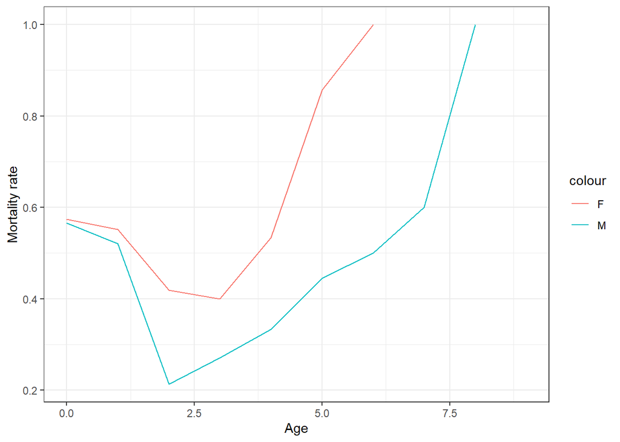

```r
ggplot(cohort,aes(x=x)) +
  geom_line(aes(y=q_M,color="M"))+
  geom_line(aes(y=q_F,color="F"))+
  labs(x="Age",y="Mortality rate")
```

Vertical life table

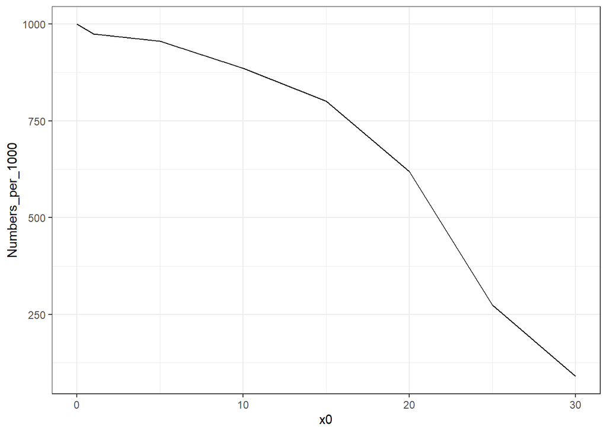

```r
vertical<-read_csv("vertical.csv")
vertical<-vertical |>
  mutate(Years_in_ageclass=x1-x0,
         annual_mortality_rate=Deaths_per_year_in_sample/Sample,
         Numbers_per_1000=NA)

vertical$Numbers_per_1000[1]<-1000
for(i in 2:nrow(vertical)) {
  vertical$Numbers_per_1000[i]<-
    vertical$Numbers_per_1000[i-1]*
    (1-vertical$annual_mortality_rate[i-1])^
     vertical$Years_in_ageclass[i-1]
}
#view(vertical)
ggplot(vertical,aes(x=x0,y=Numbers_per_1000))+
         geom_line()
```

```r
write_csv(vertical,"verticalSolved.csv")
```

### Demographic models

Read in the squirrel data, lawn pre-intervention only

```r
squirrel<-read_csv("squirrel.csv")
squirrel<-squirrel |> mutate(lxmx=lx*mx)
squirrel
```

```
## # A tibble: 6 × 4
##       x    lx    mx   lxmx
##   <dbl> <dbl> <dbl>  <dbl>
## 1  0    1      0    0
## 2  0.75 0.292  1.96 0.572
## 3  1.75 0.128  2.73 0.349
## 4  2.75 0.041  2.73 0.112
## 5  3.75 0.013  2.73 0.0355
## 6  4.75 0      0    0
```

Calculate lifetime reproductive rate

```r
R0<-with(squirrel,sum(lxmx))
R0
```

```
## [1] 1.06918
```

Mean generation time

```r
Tc<-with(squirrel,sum(x*lxmx)/sum(lxmx))
Tc
```

```
## [1] 1.385786
```

### Euler-Lotka equation

Births at time t are equal to the sum over age groups (x) number of females born x years ago, times their survival to age x (lx) times their fecundity at age x (mx).

$$B_t= \sum_{x=0}^{x_{max}} B_{t-x} l_x m_x$$

And population is growing (or declining) at rate $\lambda=e^{r_m}$. So births are

$$B_t=B_0\lambda^t$$
Substituting $B_t=B_0\lambda^t$ and $B_{t-x}=B_0\lambda^{t-x}$ into the first equation gives

$$B_0\lambda^t = \sum_{x=0}^{x_{max}} B_0\lambda^{t-x}l_x m_x$$

$B_0 \lambda^t$ cancels out, leaving

$$1 = \sum_{x=0}^{x_{max}} \lambda^{-x} l_x m_x$$

Or equivalently

$$1 = \sum_{x=0}^{x_{max}} e^{-r_m x} l_x m_x$$
Solve numerically for $r_m$

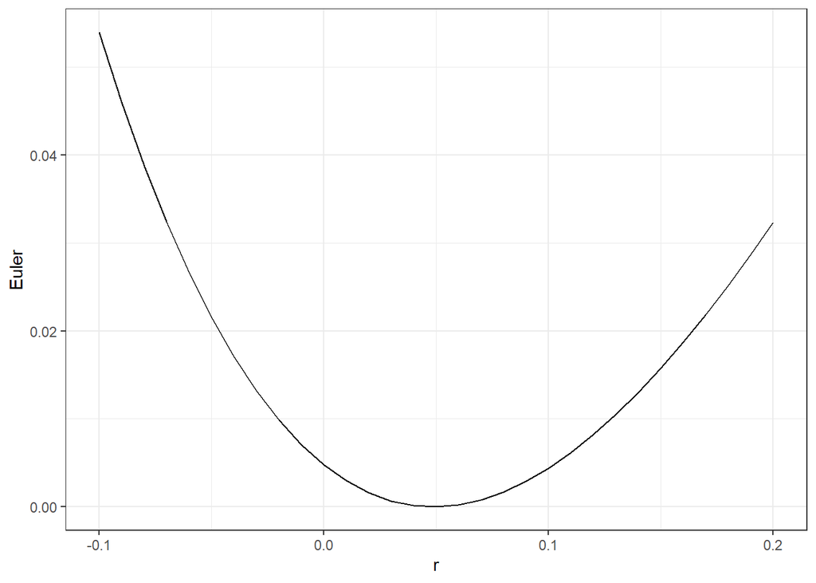

```r
EulerEquation<-function(rm,data) {
  (sum(exp(-rm*data$x)*data$lx*data$mx)-1)^2
}
rvals<-data.frame(r=seq(-0.1,0.2,by=0.01))
for(i in 1:length(rvals$r)) {
 rvals$Euler[i]<-EulerEquation(rvals$r[i],data=list(x=squirrel$x,
                        lx=squirrel$lx,
                        mx=squirrel$mx))
}
ggplot(rvals,aes(x=r,y=Euler))+geom_line()
```

Find value of rm for squirrel data

```r
solvedEuler<-optim(par=0.1,
              fn=EulerEquation,
              data=list(x=squirrel$x,
                        lx=squirrel$lx,
                        mx=squirrel$mx),
              method="L-BFGS-B")

solvedEuler
```

```
## $par
## [1] 0.04881317
##
## $value
## [1] 1.578272e-12
##
## $counts
## function gradient
##        7        7
##
## $convergence
## [1] 0
##
## $message
## [1] "CONVERGENCE: REL_REDUCTION_OF_F <= FACTR*EPSMCH"
```

```r
rm<-solvedEuler$par
rm
```

```
## [1] 0.04881317
```

$r_m$ can also be approximated by just assuming each female produces $R_0$ offspring at age %T_c% so that

$$r_c=log(R_0)/T_c$$
which is, for the squirrels

```r
rc=log(R0)/Tc
rc
```

```
## [1] 0.04827007
```

This would be exactly correct for an annual species, and it is approximate for species that reproduce multiple times.

### Matrix version

```r
Pvals<-squirrel$lx[2:6]/squirrel$lx[1:5]
Fvals<-squirrel$mx[2:6]*Pvals
Leslie<-matrix(0,5,5)
Leslie[1,]<-Fvals
for(i in 1:4) Leslie[i+1,i]<-Pvals[i]
round(Leslie,3)
```

```
##       [,1]  [,2]  [,3]  [,4] [,5]
## [1,] 0.572 1.197 0.874 0.866    0
## [2,] 0.292 0.000 0.000 0.000    0
## [3,] 0.000 0.438 0.000 0.000    0
## [4,] 0.000 0.000 0.320 0.000    0
## [5,] 0.000 0.000 0.000 0.317    0
```

Calculate $r_m$ with matrix multiplication %*%

```r
nyear<-100
N<-matrix(NA,5,nyear)
N[,1]<-rep(1,5)
for(i in 2:nyear) {
  N[,i]<-Leslie %*% N[,i-1]
}
N[1:5,1:5]
```

```
##      [,1]      [,2]      [,3]       [,4]      [,5]
## [1,]    1 3.5090952 3.0183529 3.18715307 3.3070677
## [2,]    1 0.2920000 1.0246558 0.88135905 0.9306487
## [3,]    1 0.4383562 0.1280000 0.44916419 0.3863492
## [4,]    1 0.3203125 0.1404110 0.04100000 0.1438729
## [5,]    1 0.3170732 0.1015625 0.04452055 0.0130000
```

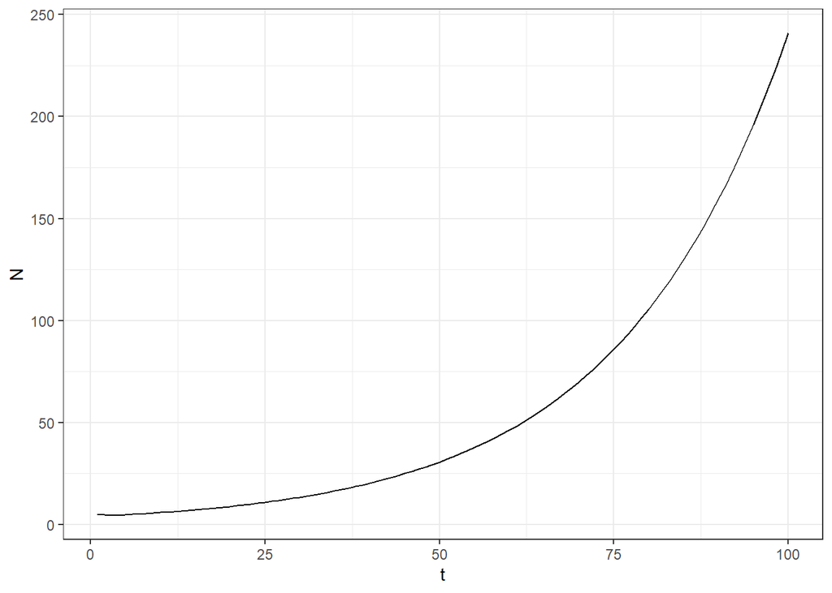

```r
sumTab<-data.frame(t=1:nyear,N=colSums(N))
view(sumTab)
sumTab$lambda<-NA
sumTab$lambda[2:nyear]<-sumTab$N[2:nyear]/sumTab$N[1:(nyear-1)]

ggplot(sumTab,
       aes(x=t,y=N,group=1))+
  geom_line()
```

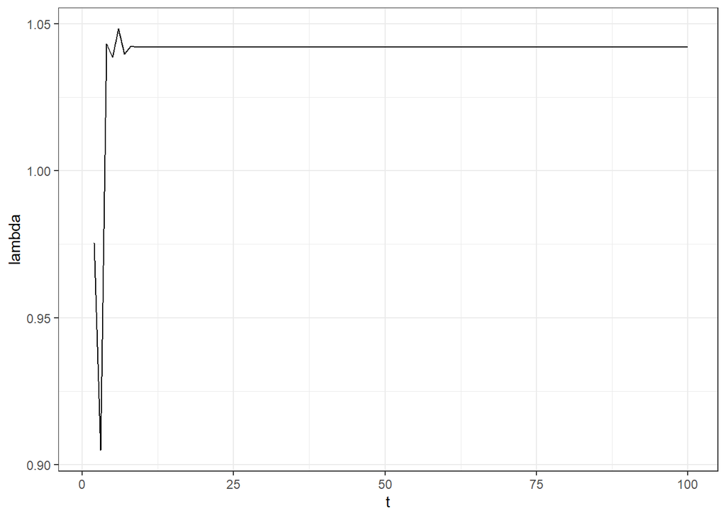

```r
ggplot(sumTab,
       aes(x=t,y=lambda,group=1))+
  geom_line()
```

```r
lambda<-sumTab$lambda[nyear]
lambda
```

```
## [1] 1.042083
```

```r
rm<-log(lambda)
rm
```

```
## [1] 0.04122119
```

The stable age structure can be calculated by dividing the numbers by the total in the last year.

```r
round(N[,nyear]/sumTab$N[nyear],3)
```

```
## [1] 0.692 0.194 0.082 0.025 0.008
```

Eigenvalue method

```r
eigen(Leslie)
```

```
## eigen() decomposition
## $values
## [1]  1.0420826+0.000000i -0.3482884+0.000000i -0.0607371+0.306748i
## [4] -0.0607371-0.306748i  0.0000000+0.000000i
##
## $vectors
##                [,1]          [,2]                   [,3]                   [,4]
## [1,] -0.95614168+0i  0.4693970+0i  0.26385862+0.2620187i  0.26385862-0.2620187i
## [2,] -0.26791866+0i -0.3935358+0i  0.19215472-0.2892199i  0.19215472+0.2892199i
## [3,] -0.11270105+0i  0.4953046+0i -0.45003516-0.1854890i -0.45003516+0.1854890i
## [4,] -0.03464174+0i -0.4555198+0i -0.09684568+0.4891116i -0.09684568-0.4891116i
## [5,] -0.01054040+0i  0.4146940+0i  0.50557511+0.0000000i  0.50557511+0.0000000i
##      [,5]
## [1,] 0+0i
## [2,] 0+0i
## [3,] 0+0i
## [4,] 0+0i
## [5,] 1+0i
```

```r
lambda2<-Re(eigen(Leslie)$values[1])  #Re for just real number
lambda2
```

```
## [1] 1.042083
```

```r
#Stable age structure is first eigenvector divided by its sum
round(Re(eigen(Leslie)$vectors[,1]/
           sum(eigen(Leslie)$vectors[,1])),3)
```

```
## [1] 0.692 0.194 0.082 0.025 0.008
```

### Elasticity analysis

```r
#Function to calculate left eigenvalue #https://stackoverflow.com/questions/14912279/how-to-obtain-right-eigenvectors-of-matrix-in-r
left_eigen<-function(A) {
  Re(eigen(t(A))$vectors)
}
w<-Re(eigen(Leslie)$vectors)[,1]
v<-left_eigen(Leslie)[,1]
w/sum(w)
```

```
## [1] 0.691881874 0.193870920 0.081552570 0.025067407 0.007627229
```

```r
v/v[1]
```

```
## [1] 1.0000000 1.6087759 1.0944640 0.8306537 0.0000000
```

```r
elasticityFunc<-function(A) {
 w<-Re(eigen(A)$vectors)[,1]
 v<-left_eigen(A)[,1]
 w<-w/sum(w)
 v<-v/v[1]
 lambda<-Re(eigen(A)$values)[1]
 sensitivity<-outer(v,w)/sum(v*w)
 elasticity<-(A/lambda)*sensitivity
 elasticity
}
elasticityFunc(Leslie)
```

```
##           [,1]      [,2]       [,3]       [,4] [,5]
## [1,] 0.3411457 0.1998810 0.06143887 0.01869393    0
## [2,] 0.2800138 0.0000000 0.00000000 0.00000000    0
## [3,] 0.0000000 0.0801328 0.00000000 0.00000000    0
## [4,] 0.0000000 0.0000000 0.01869393 0.00000000    0
## [5,] 0.0000000 0.0000000 0.00000000 0.00000000    0
```

Calculate some summaries

Elasticity of reproductive output

```r
elasVals<-elasticityFunc(Leslie)
```

Show elasticity for reproduction compared to survival

```r
reproElasticity<-elasVals[1,]
survivalElasticity<-c(elasVals[2,1],elasVals[3,2],
                      elasVals[4,3],elasVals[5,4])
reproElasticity
```

```
## [1] 0.34114571 0.19988098 0.06143887 0.01869393 0.00000000
```

```r
survivalElasticity
```

```
## [1] 0.28001378 0.08013280 0.01869393 0.00000000
```

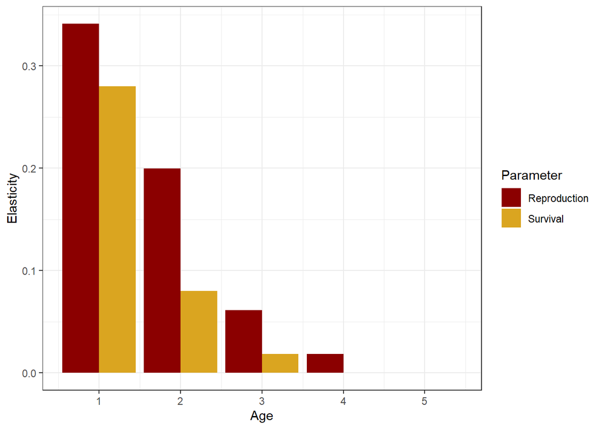

```r
elastSum<-data.frame(Age=rep(1:5,2),
                     Parameter=rep(c("Reproduction","Survival"),each=5),
                     Elasticity=c(reproElasticity,survivalElasticity,0))
ggplot(elastSum,aes(x=Age,y=Elasticity,fill=Parameter)) +
  geom_col(position = position_dodge())+
  scale_fill_manual(values=c("darkred","goldenrod"))
```

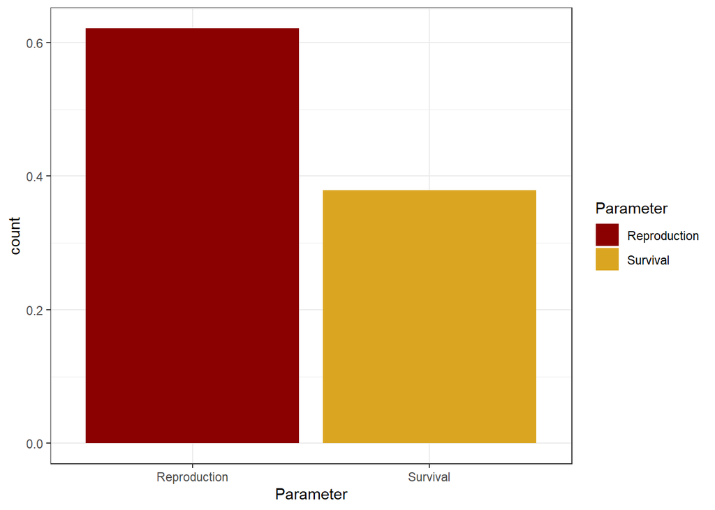

```r
ggplot(elastSum,aes(x=Parameter,weight=Elasticity,fill=Parameter)) +
  geom_bar()+
  scale_fill_manual(values=c("darkred","goldenrod"))
```

Reproduction is more important as a whole, particularly or younger animals.

Try changing a parameter to see how it influences lambda.

```r
newLeslie<-Leslie
newLeslie[1,1]<-Leslie[1,1]*1.1
newLambda<-Re(eigen(newLeslie)$values[1])
(newLambda-lambda)/lambda
```

```
## [1] 0.03468646
```

A 10% increase in F1 is a 3.4% increase in lambda

### R library popbio

https://www.r-bloggers.com/2013/04/demographic-analysis-using-the-popbio-library-and-some-other-fun-stuff/

Library does all this work for you.

```r
library(popbio)
eigen.analysis(Leslie)
```

```
## $lambda1
## [1] 1.042083
##
## $stable.stage
## [1] 0.691881874 0.193870920 0.081552570 0.025067407 0.007627229
##
## $sensitivities
##           [,1]      [,2]       [,3]       [,4]        [,5]
## [1,] 0.6211595 0.1740539 0.07321648 0.02250508 0.006847593
## [2,] 0.9993064 0.2800138 0.11778891 0.03620563 0.011016243
## [3,] 0.6798367 0.1904958 0.08013280 0.02463100 0.007494444
## [4,] 0.5159684 0.1445785 0.06081754 0.01869393 0.005687979
## [5,] 0.0000000 0.0000000 0.00000000 0.00000000 0.000000000
##
## $elasticities
##           [,1]      [,2]       [,3]       [,4] [,5]
## [1,] 0.3411457 0.1998810 0.06143887 0.01869393    0
## [2,] 0.2800138 0.0000000 0.00000000 0.00000000    0
## [3,] 0.0000000 0.0801328 0.00000000 0.00000000    0
## [4,] 0.0000000 0.0000000 0.01869393 0.00000000    0
## [5,] 0.0000000 0.0000000 0.00000000 0.00000000    0
##
## $repro.value
## [1] 1.0000000 1.6087759 1.0944640 0.8306537 0.0000000
##
## $damping.ratio
## [1] 2.991989
```

### Monte Carlo estimation of uncertainty

```r
getLeslie<-function(lx,mx) {
  Pvals<-lx[2:6]/lx[1:5]
  Fvals<-mx[2:6]*Pvals
  Leslie<-matrix(0,5,5)
  Leslie[1,]<-Fvals
  for(i in 1:4) Leslie[i+1,i]<-Pvals[i]
  Leslie
}
#Each vector has the following CV
squirrel.lx.cv<-0.02
squirrel.mx.cv<-0.05
```

The distributions of the survivals and fecundities look like this.

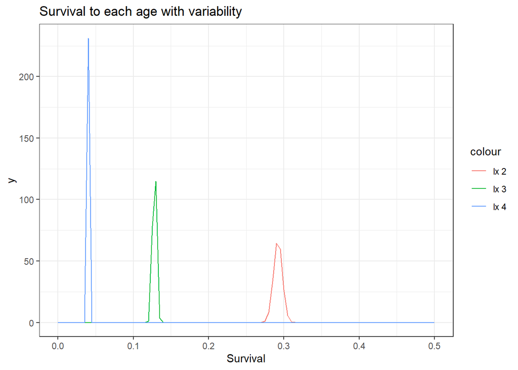

```r
ggplot(data.frame(Survival=0:0.5),aes(x=Survival))+
  stat_function(aes(color="lx 2"),fun = dnorm,
                args=list(mean=squirrel$lx[2],
                          sd=squirrel.lx.cv*squirrel$lx[2]))+
  stat_function(aes(color="lx 3"),fun = dnorm,
                args=list(mean=squirrel$lx[3],
                          sd=squirrel.lx.cv*squirrel$lx[3]))+
  stat_function(aes(color="lx 4"),fun = dnorm,
                args=list(mean=squirrel$lx[4],
                          sd=squirrel.lx.cv*squirrel$lx[4]))+
  xlim(0,0.5)+
  ggtitle("Survival to each age with variability")
```

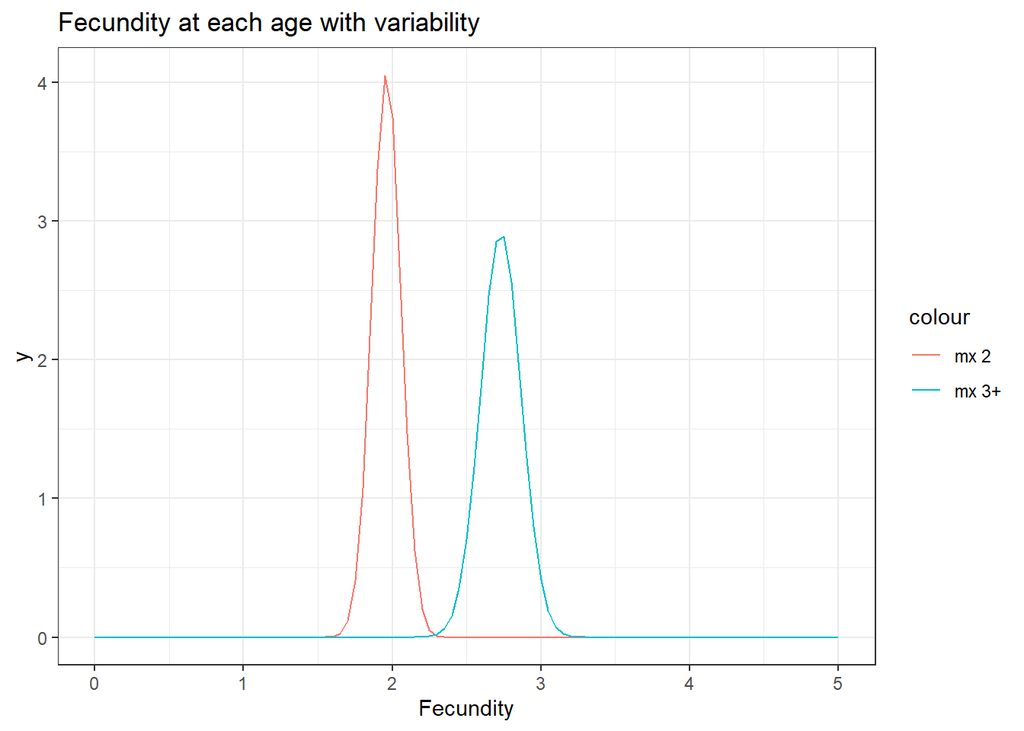

```r
ggplot(data.frame(Fecundity=0:5),aes(x=Fecundity))+
  stat_function(aes(color="mx 2"),fun = dnorm,
                args=list(mean=squirrel$mx[2],
                          sd=squirrel.mx.cv*squirrel$mx[2]))+
  stat_function(aes(color="mx 3+"),fun = dnorm,
                args=list(mean=squirrel$mx[3],
                          sd=squirrel.mx.cv*squirrel$mx[3]))+
  ggtitle("Fecundity at each age with variability")
```

```r
nsim<-100000
lambdaSims<-NULL
for(sim in 1:nsim) {
  lx<-c(1,rnorm(5,squirrel$lx[2:6],squirrel.lx.cv*squirrel$lx[2:6]))
  mx<-rnorm(6,squirrel$mx,squirrel.mx.cv*squirrel$mx)
  A<-getLeslie(lx,mx)
  lambdaSims[sim]<-Re(eigen(A)$values[1])
}
summary(lambdaSims)
```

```
##    Min. 1st Qu.  Median    Mean 3rd Qu.    Max.
##  0.9481  1.0270  1.0423  1.0423  1.0574  1.1403
```

```r
#or more efficiently
getLambda<-function() {
    lx<-c(1,rnorm(5,squirrel$lx[2:6],squirrel.lx.cv*squirrel$lx[2:6]))
    mx<-rnorm(6,squirrel$mx,squirrel.mx.cv*squirrel$mx)
    A<-getLeslie(lx,mx)
    Re(eigen(A)$values[1])
}
lambdaSims<-replicate(nsim,getLambda())
#summarize results
summary(lambdaSims)
```

```
##    Min. 1st Qu.  Median    Mean 3rd Qu.    Max.
##  0.9394  1.0269  1.0420  1.0422  1.0574  1.1538
```

```r
mean(lambdaSims,na.rm=TRUE)
```

```
## [1] 1.042232
```

```r
confidenceInterval<-quantile(lambdaSims,c(0.025,0.975))
round(confidenceInterval,3)
```

```
##  2.5% 97.5%
## 0.999 1.087
```

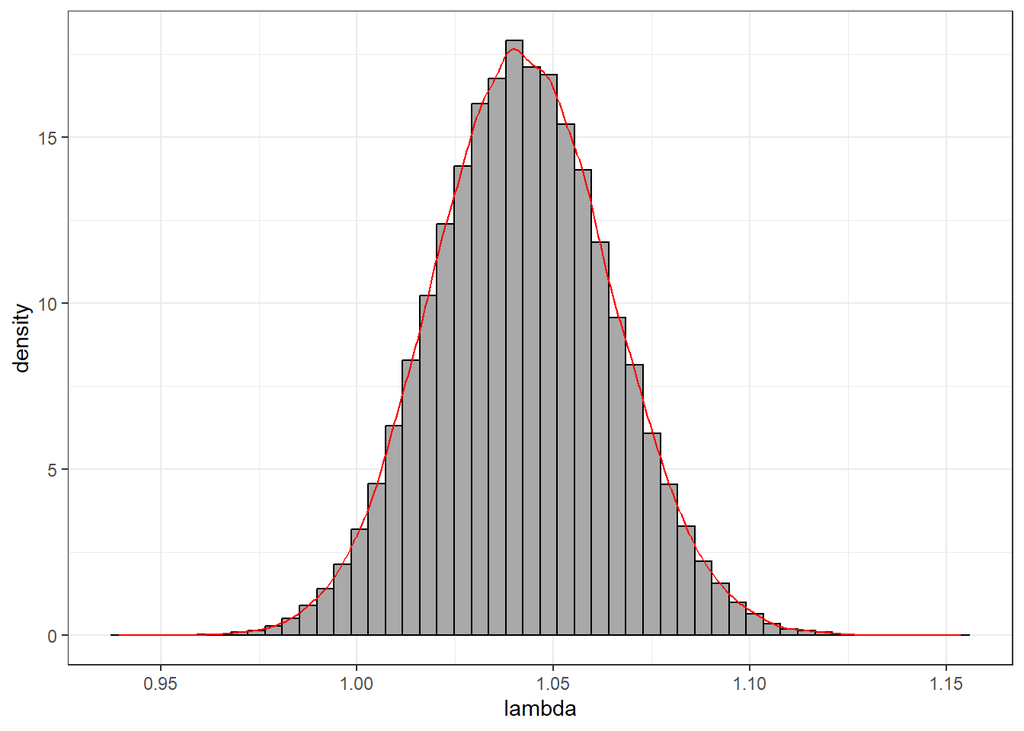

```r
ggplot(data.frame(lambda<-lambdaSims),
       aes(x=lambda,y=after_stat(density)))+
  geom_histogram(fill="darkgrey",color="black",bins=50)+
  geom_density(color="red")
```